# Everything you needed to know to help your project students but were too busy to find out last year.

# Renaming columns

Use `rename` for simple cases

```r
mtcars %>%
  select(cyl, mpg) %>%
  rename(MPG = mpg, Cylinders = cyl) %>%
  head()
```

```
##                   Cylinders  MPG
## Mazda RX4                 6 21.0
## Mazda RX4 Wag             6 21.0
## Datsun 710                4 22.8
## Hornet 4 Drive            6 21.4
## Hornet Sportabout         8 18.7
## Valiant                   6 18.1
```

Use back-ticks to wrap the new name if you want to include spaces:

```r
mtcars %>%
  select(mpg) %>%
  rename(`Miles per gallon` = mpg) %>%
  head()
```

```
##                   Miles per gallon
## Mazda RX4                     21.0
## Mazda RX4 Wag                 21.0
## Datsun 710                    22.8
## Hornet 4 Drive                21.4
## Hornet Sportabout             18.7
## Valiant                       18.1
```

## Tidying messy names

`#extension`

The janitor package has a really great function to tidy messy names as they come from online survey systems. This is a real example:

```r
rio::import('sleep.xlsx') %>%
  glimpse
```

```
## * `` -> ...1
```

```
## Rows: 241
## Columns: 12
## $ ...1                                                                                        <chr> …
## $ uniqueid                                                                                    <chr> …
## $ `Start time`                                                                                <dttm> …
## $ `Completion time`                                                                           <dttm> …
## $ `My sleep is affected by my study commitments`                                              <chr> …
## $ `I achieve good quality sleep`                                                              <chr> …
## $ `My electronic device usage negatively affects my sleep`                                    <chr> …
## $ `Tiredness interferes with my concentration`                                                <chr> …
## $ `My sleep is disturbed by external factors e.g. loud cars, housemates, lights, children...` <chr> …
## $ `I often achieve eight hours of sleep`                                                      <chr> …
## $ `I regularly stay up past 11pm`                                                             <chr> …
## $ `My other personal commitments affect my sleep`                                             <chr> …
```

```r
rio::import('sleep.xlsx') %>%
  janitor::clean_names() %>%
  glimpse
```

```
## * `` -> ...1
```

```
## Rows: 241
## Columns: 12
## $ x1                                                                                 <chr> …
## $ uniqueid                                                                           <chr> …
## $ start_time                                                                         <dttm> …
## $ completion_time                                                                    <dttm> …
## $ my_sleep_is_affected_by_my_study_commitments                                       <chr> …
## $ i_achieve_good_quality_sleep                                                       <chr> …
## $ my_electronic_device_usage_negatively_affects_my_sleep                             <chr> …
## $ tiredness_interferes_with_my_concentration                                         <chr> …
## $ my_sleep_is_disturbed_by_external_factors_e_g_loud_cars_housemates_lights_children <chr> …
## $ i_often_achieve_eight_hours_of_sleep                                               <chr> …
## $ i_regularly_stay_up_past_11pm                                                      <chr> …
## $ my_other_personal_commitments_affect_my_sleep                                      <chr> …
```

This makes working with the dataset much easier:

- Everything is lower case, so no guessing whether you need to capitalise names
- No spaces (so no escaping of spaces needed with back ticks)
- No special characters which can mess things up

## Renaming programatically

`#extension` You can do similar things yourself by doing string replacements and the `set_names` function.

```r
# here the dot refers to the data coming from the pipe
rio::import('sleep.xlsx') %>% names(.)
```

```
## * `` -> ...1
```

```
##  [1] "...1"
##  [2] "uniqueid"
##  [3] "Start time"
##  [4] "Completion time"
##  [5] "My sleep is affected by my study commitments"
##  [6] "I achieve good quality sleep"
##  [7] "My electronic device usage negatively affects my sleep"
##  [8] "Tiredness interferes with my concentration"
##  [9] "My sleep is disturbed by external factors e.g. loud cars, housemates, lights, children..."
## [10] "I often achieve eight hours of sleep"
## [11] "I regularly stay up past 11pm"
## [12] "My other personal commitments affect my sleep"
```

```r
rio::import('sleep.xlsx') %>%
  set_names(tolower(str_replace_all(names(.), " ", "_"))) %>%
  glimpse
```

```
## * `` -> ...1
```

```
## Rows: 241
## Columns: 12
## $ ...1                                                                                        <chr> …
## $ uniqueid                                                                                    <chr> …
## $ start_time                                                                                  <dttm> …
## $ completion_time                                                                             <dttm> …
## $ my_sleep_is_affected_by_my_study_commitments                                                <chr> …
## $ i_achieve_good_quality_sleep                                                                <chr> …
## $ my_electronic_device_usage_negatively_affects_my_sleep                                      <chr> …
## $ tiredness_interferes_with_my_concentration                                                  <chr> …
## $ `my_sleep_is_disturbed_by_external_factors_e.g._loud_cars,_housemates,_lights,_children...` <chr> …
## $ i_often_achieve_eight_hours_of_sleep                                                        <chr> …
## $ i_regularly_stay_up_past_11pm                                                               <chr> …
## $ my_other_personal_commitments_affect_my_sleep                                               <chr> …
```

# Tables/descriptive statistics

In stage 1 and 2 students learn how to use `group_by` and `summarise` to make tables of descriptive statistics, and the [better tables](https://www.andywills.info/rminr/better-tables.html) worksheet recommends the same:

```r
mtcars %>%
  group_by(cyl) %>%
  summarise(MPG = mean(mpg), SD=sd(mpg))
```

```
## # A tibble: 3 x 3
##     cyl   MPG    SD
##   <dbl> <dbl> <dbl>
## 1     4  26.7  4.51
## 2     6  19.7  1.45
## 3     8  15.1  2.56
```

### Summarising multiple variables

`#extension` It’s also possible to use `pivot_longer` to simplify summarising multiple variables. We don’t show this technique explicitly, but we do teach `pivot_longer` and `pivot_wider`, so students could combine the ideas for themselves:

```r
mtcars %>%
  select(cyl, mpg, wt, disp, drat) %>%
  pivot_longer(-cyl) %>%
  group_by(name) %>%
  summarise(M=mean(value), SD=sd(value), Med = median(value), IQR = IQR(value))
```

```
## # A tibble: 4 x 5
##   name       M      SD    Med     IQR
##   <chr>  <dbl>   <dbl>  <dbl>   <dbl>
## 1 disp  231.   124.    196.   205.
## 2 drat    3.60   0.535   3.70   0.840
## 3 mpg    20.1    6.03   19.2    7.38
## 4 wt      3.22   0.978   3.32   1.03
```

### Comparing variables in tables

`#extension` Using `pivot_longer` and `pivot_wider` you can compare variables in a table side by side:

```r
mtcars %>%
  select(cyl, am, mpg, wt) %>%
  # note here we have to select multiple columns to exclude (cyl and am) by adding a hyhen in front of the name
  pivot_longer(c(-cyl, -am)) %>%
  # recode am to have nice labels in the table below
  mutate(am=factor(am, levels=c(0,1), labels=c("Manual", "Auto"))) %>%
  group_by(am, name) %>%
  summarise(M=mean(value), SD=sd(value)) %>%
  pivot_wider(names_from=am, values_from=c(M, SD)) %>%
  # replace underscores in column names with spaces
  set_names(str_replace(names(.), "_", " "))
```

```
## # A tibble: 2 x 5
##   name  `M Manual` `M Auto` `SD Manual` `SD Auto`
##   <chr>      <dbl>    <dbl>       <dbl>     <dbl>
## 1 mpg        17.1     24.4        3.83      6.17
## 2 wt          3.77     2.41       0.777     0.617
```

See reshaping data below for a guide to `pivot_longer` and `pivot_wider`. See also various techniques for renaming columns.

# Reshaping data

There are two functions to reshape data:

- `pivot_longer`
- `pivot_wider`

## Reshaping to long form

### Select only what you need

It’s best to select only the data you need before reshaping. Although not strictly necessary it does:

- make it easier to check the output is as desired
- avoids an error where columns are of different types

> **If you try and `pivot_longer` a mix of numeric and character (text) data this will fail***. If you want to keep text columns, exclude from the pivoting (see below for how).

### Simplest case: make everything long

```r
mtcars %>%
  select(mpg, wt) %>%
  pivot_longer(cols=everything())
```

```
## # A tibble: 64 x 2
##    name  value
##    <chr> <dbl>
##  1 mpg   21
##  2 wt     2.62
##  3 mpg   21
##  4 wt     2.88
##  5 mpg   22.8
##  6 wt     2.32
##  7 mpg   21.4
##  8 wt     3.22
##  9 mpg   18.7
## 10 wt     3.44
## # … with 54 more rows
```

In the code above writing `cols=` is optional, but makes things explicit and should be encouraged.

### Exclude some variables but keep them as index columns

Imagine we have one column which we’d like to keep as an index. We can exclude from pivoting by writing a hyphen in front of the variable name:

```r
mtcars %>%
  select(cyl, mpg, wt) %>%
  pivot_longer(cols = -cyl) %>%
  sample_n(6)
```

```
## # A tibble: 6 x 3
##     cyl name  value
##   <dbl> <chr> <dbl>
## 1     4 wt     2.78
## 2     8 mpg   15.2
## 3     6 wt     2.62
## 4     8 mpg   14.7
## 5     8 mpg   10.4
## 6     6 mpg   17.8
```

If we have two columns to exclude we need to specify them in a vector using `c()`:

```r
mtcars %>%
  select(cyl, am, mpg, wt) %>%
  pivot_longer(cols = c(-cyl, -am)) %>%
  sample_n(6)
```

```
## # A tibble: 6 x 4
##     cyl    am name  value
##   <dbl> <dbl> <chr> <dbl>
## 1     4     0 mpg   21.5
## 2     6     1 mpg   21
## 3     4     1 wt     2.14
## 4     6     0 wt     3.46
## 5     4     1 mpg   27.3
## 6     4     0 wt     2.46
```

You can also do this the other way, by specifying only which columns you do want to pivot:

```r
mtcars %>%
  select(cyl, am, mpg, wt) %>%
  pivot_longer(cols = c(mpg, wt)) %>%
  sample_n(6)
```

```
## # A tibble: 6 x 4
##     cyl    am name  value
##   <dbl> <dbl> <chr> <dbl>
## 1     4     1 mpg   32.4
## 2     8     1 wt     3.57
## 3     6     1 mpg   21
## 4     4     1 wt     1.84
## 5     8     0 mpg   17.3
## 6     8     0 wt     5.34
```

## Reshape to wider form

Use `pivot_wider`. With a simple table like this:

```r
mpg.summary <- mtcars %>%
  group_by(cyl) %>%
  summarise(M = mean(mpg))
mpg.summary
```

```
## # A tibble: 3 x 2
##     cyl     M
##   <dbl> <dbl>
## 1     4  26.7
## 2     6  19.7
## 3     8  15.1
```

We can spread the data wide to enable comparison (and the table is more in line with expected APA format):

```r
mpg.summary %>%
  pivot_wider(names_from=cyl, values_from=M)
```

```
## # A tibble: 1 x 3
##     `4`   `6`   `8`
##   <dbl> <dbl> <dbl>
## 1  26.7  19.7  15.1
```

This is especially useful when you have more rows in the table:

```r
diamonds %>%
  # this is a quick way of renaming color to be capitalised
  group_by(cut, Color=color) %>%
  summarise(M = mean(price)) %>%
  pivot_wider(names_from=cut, values_from=M) %>%
  pander::pander()
```

| Color | Fair | Good | Very Good | Premium | Ideal |
| --- | --- | --- | --- | --- | --- |
| D | 4291 | 3405 | 3470 | 3631 | 2629 |
| E | 3682 | 3424 | 3215 | 3539 | 2598 |
| F | 3827 | 3496 | 3779 | 4325 | 3375 |
| G | 4239 | 4123 | 3873 | 4501 | 3721 |
| H | 5136 | 4276 | 4535 | 5217 | 3889 |
| I | 4685 | 5079 | 5256 | 5946 | 4452 |
| J | 4976 | 4574 | 5104 | 6295 | 4918 |

# Data Visualisation

In stage 1 and 2 students are taught scatter, density and boxplots:

## Scatter plots

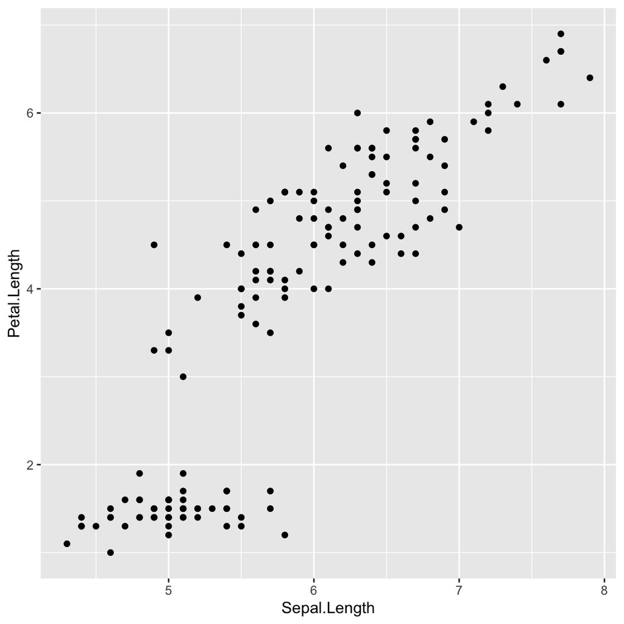

```r
iris %>%
  ggplot(aes(x = Sepal.Length, y=Petal.Length)) +
  geom_point()
```

`#extension` Adding jitter to a plot can be useful. We don’t teach it, but I recommend using `geom_jitter` rather than `geom_point`. This is especially helpful with survey data which is not often truly continuous; adding jitter helps show points which overlap on scale boundaries:

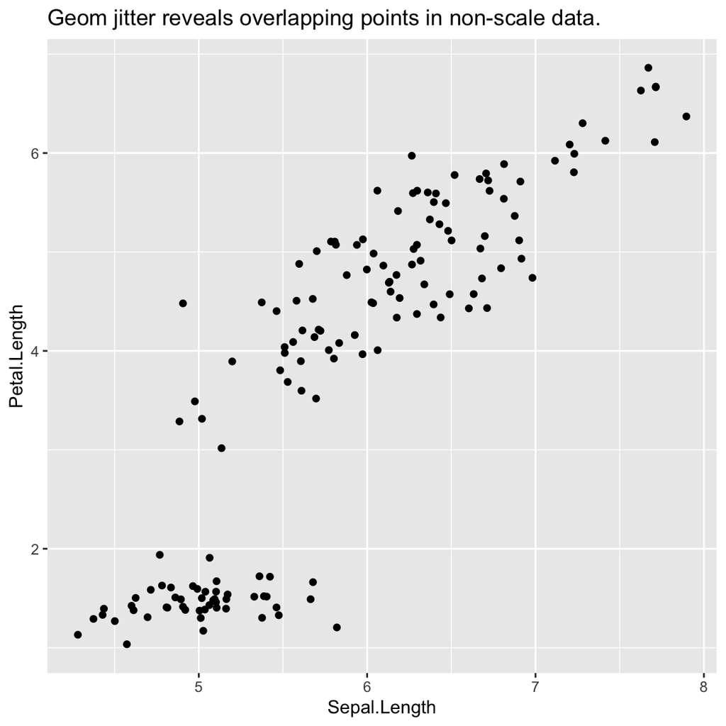

```r
iris %>%
  ggplot(aes(x = Sepal.Length, y=Petal.Length)) +
  geom_jitter() +
  ggtitle("Geom jitter reveals overlapping points in non-scale data.")
```

## Color dimensions

With a categorical color dimension:

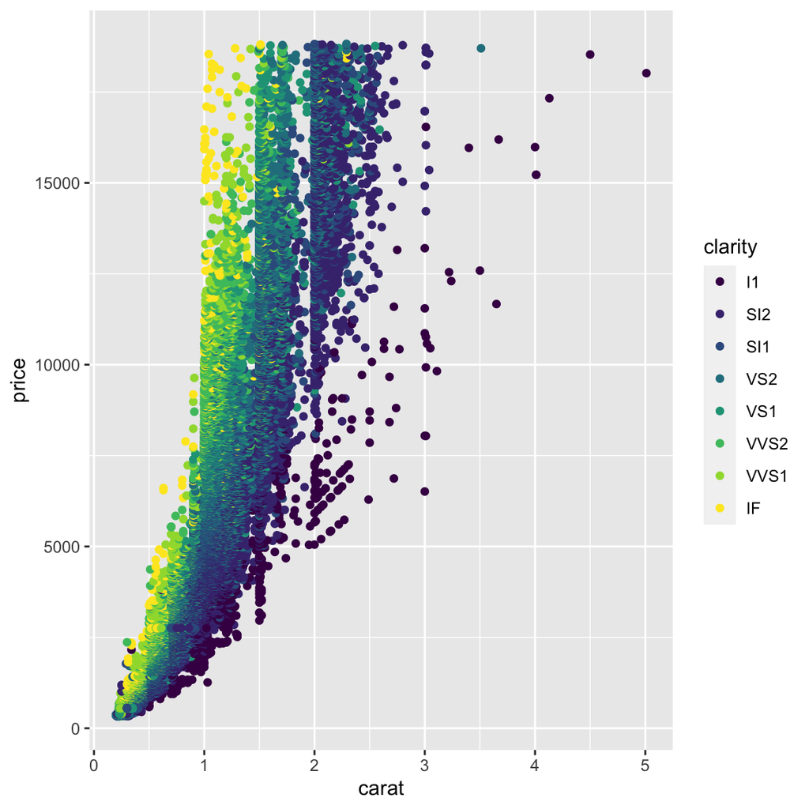

```r
diamonds %>%
  ggplot(aes(x = carat, y=price, color=clarity)) +
  geom_point()
```

Or a continuous color dimension:

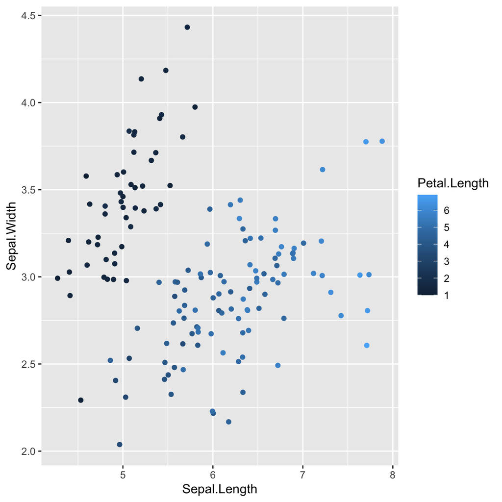

```r
iris %>%
  ggplot(aes(x = Sepal.Length, y=Sepal.Width, color=Petal.Length)) +
  geom_jitter()
```

See also converting continuous and categorical data

## Smoothed lines

We show students how to add a smoothed line:

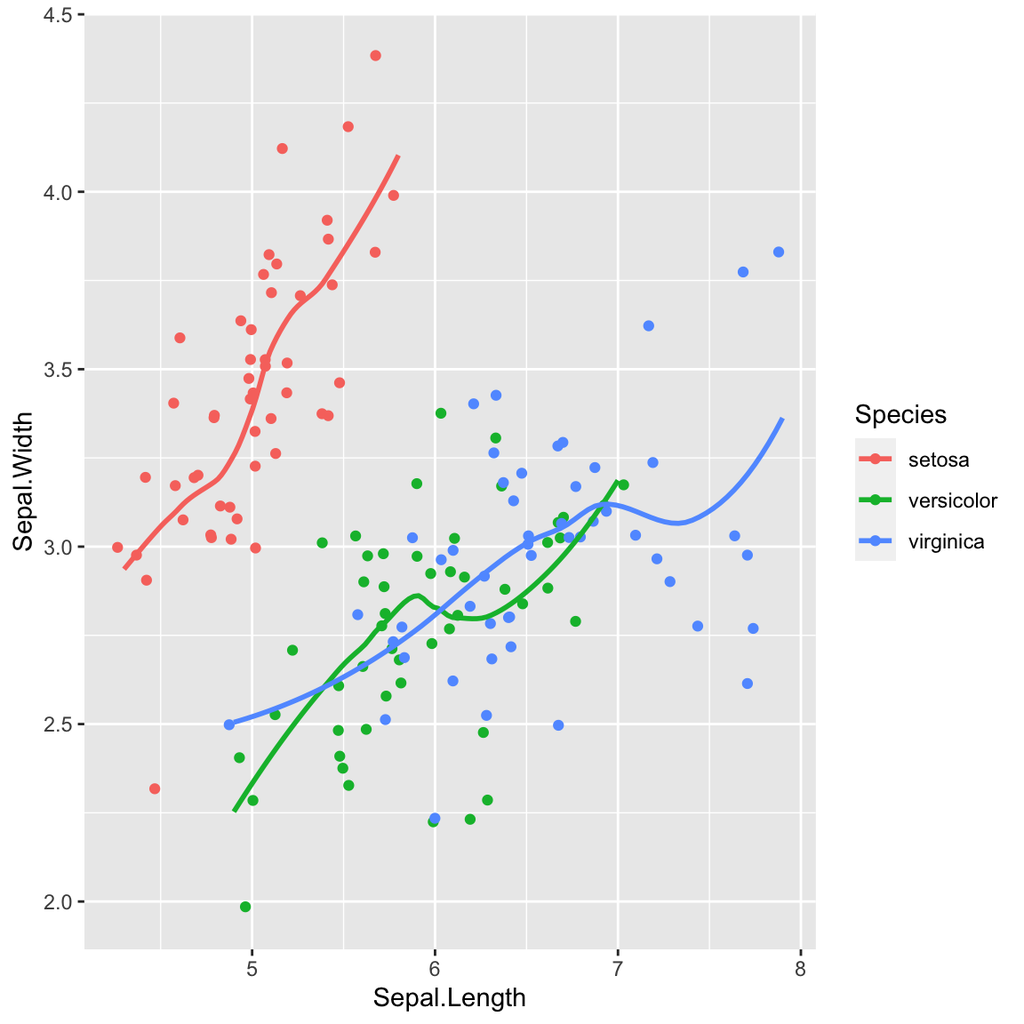

```r
iris %>%
  ggplot(aes(x = Sepal.Length, y=Sepal.Width, color=Species)) +
  geom_jitter() +
  geom_smooth(se=F)
```

And also how to use a linear fit for the lines:

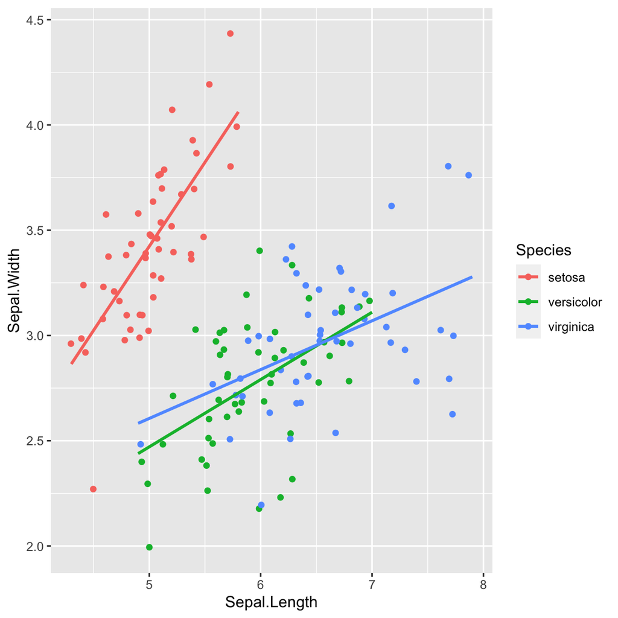

```r
iris %>%
  ggplot(aes(x = Sepal.Length, y=Sepal.Width, color=Species)) +
  geom_jitter() +
  geom_smooth(se=F, method=lm)
```

## Facets/panels

Create a grid of plots using a single faceting variable:

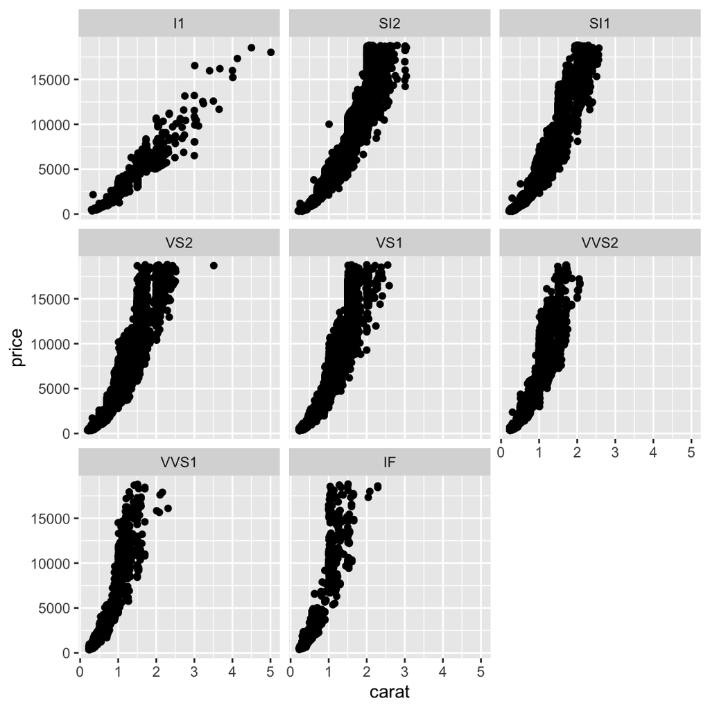

```r
diamonds %>%
  ggplot(aes(x = carat, y=price)) +
  geom_point() +
  facet_wrap(~clarity)
```

`#extension` Or a two-way grid of facets using two variables:

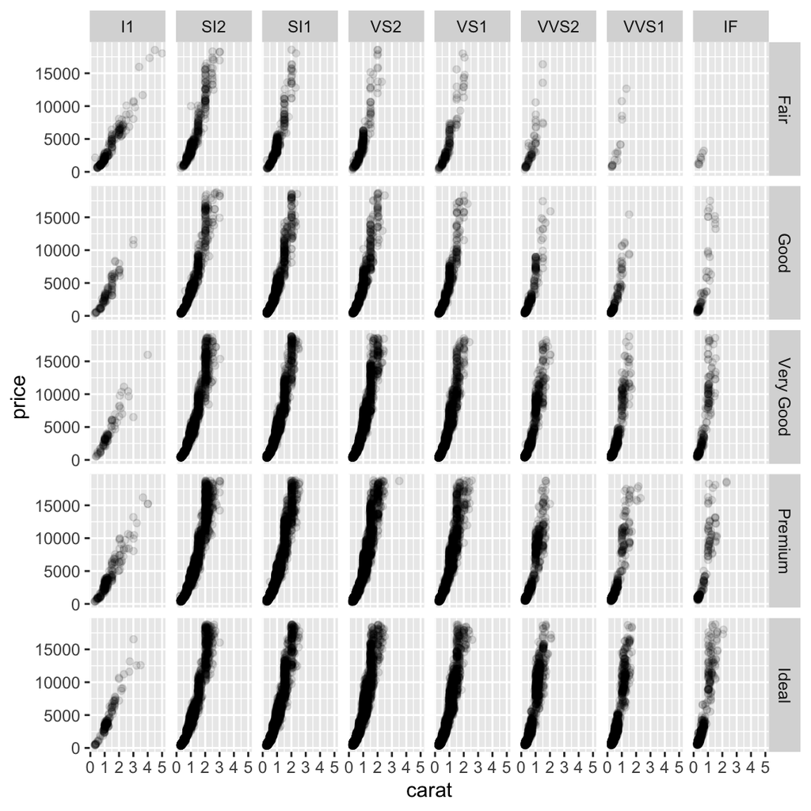

```r
diamonds %>%
  ggplot(aes(x = carat, y=price)) +
  # note adding alpha=.1 makes points partly transparent and makes it easier to see
  # where most of the density is in large datasets. The term alpha refers to the alpha-channel
  # in computer graphics which controls the transparency of images
  geom_point(alpha=.1) +
  facet_grid(cut~clarity)
```

### Combining two plots

`#extension`

You can use the `cowplot` package if you want to combine 2 plots and can’t use faceting.

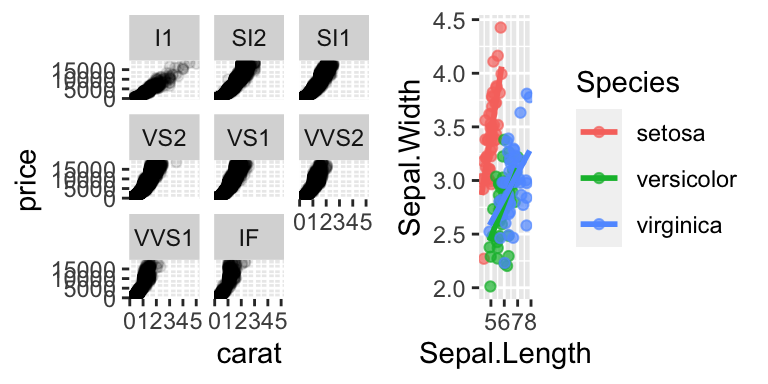

```r
plot1 <- diamonds %>%
  ggplot(aes(x = carat, y=price)) +
  geom_point(alpha=.1) +
  facet_wrap(~clarity)

plot2 <- iris %>%
  ggplot(aes(x = Sepal.Length, y=Sepal.Width, color=Species)) +
  geom_jitter(alpha=.7) +
  geom_smooth(se=F, method=lm)

cowplot::plot_grid(plot1, plot2)
```

## Boxplots (and similar)

Where the x axis is a categorical variable we teach students to use a boxplot (in preference to bar plots):

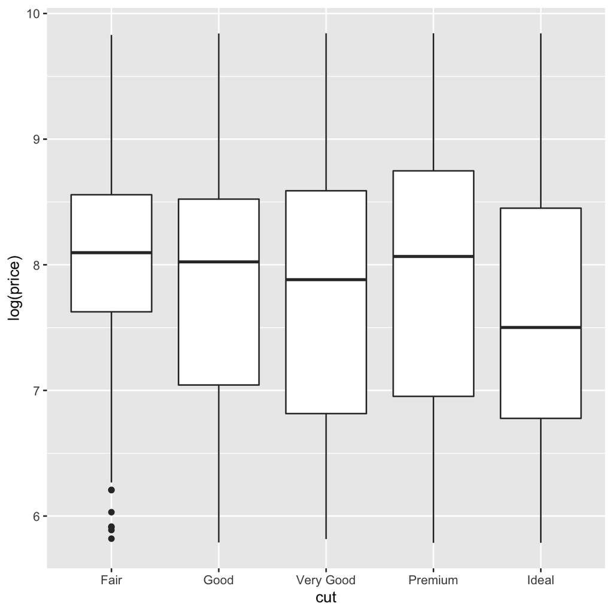

```r
diamonds %>%
  ggplot(aes(x = cut, y=log(price))) +
  geom_boxplot()
```

`#extension` If you don’t like boxplots you can use a point-range plot. Bar charts are not recommended because of the [‘within-bar bias’](https://doi.org/10.3758/s13423-012-0247-5), whereby readers perceive points inside the bar (e.g. the bottom of an error bar) as more likely than those outside the bar (e.g. the top of an error bar), even though this is not the case.

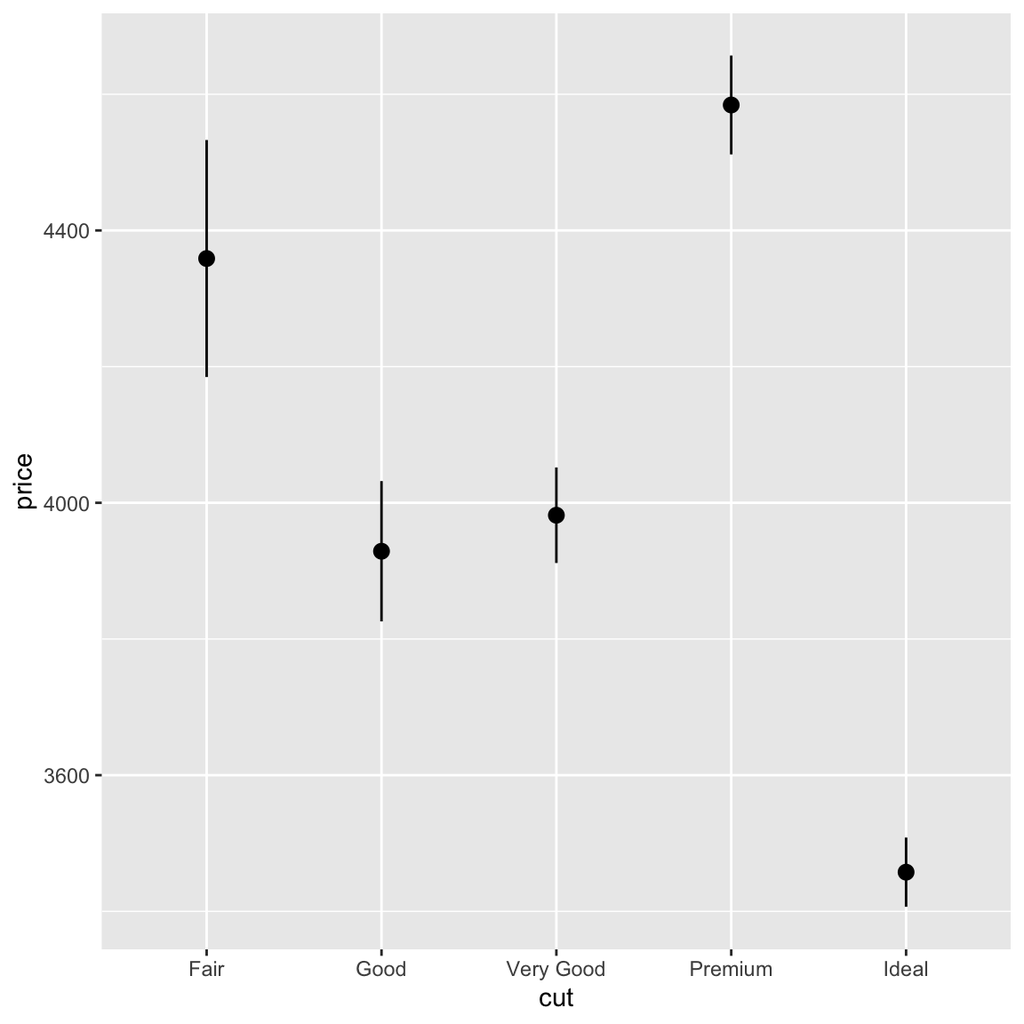

```r
diamonds %>%
  ggplot(aes(x = cut, y=price)) +
  # set the error bars to be 95% CI. Default is the SE.
  # could also use the median_hilow function here
  stat_summary(fun.data=mean_cl_normal)
```

`#extension` Combining boxplots and facets can be useful for experimental data:

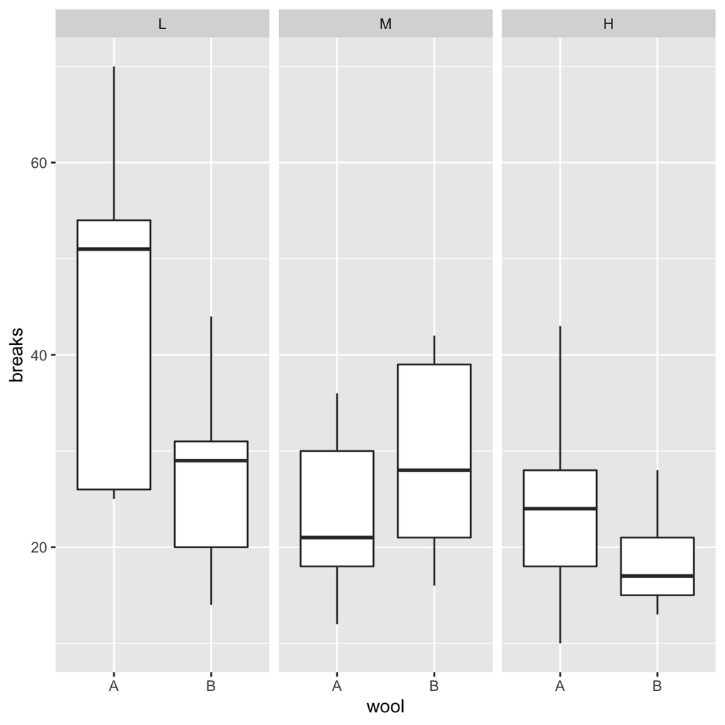

```r
warpbreaks %>%
  ggplot(aes(wool, breaks)) +
  geom_boxplot() +
  # note the dot here means 'skip the horizontal-facet`
  facet_grid(.~tension)
```

`#extension` Some people like violin plots + boxplots. Day 9 in this data is a good example of why:

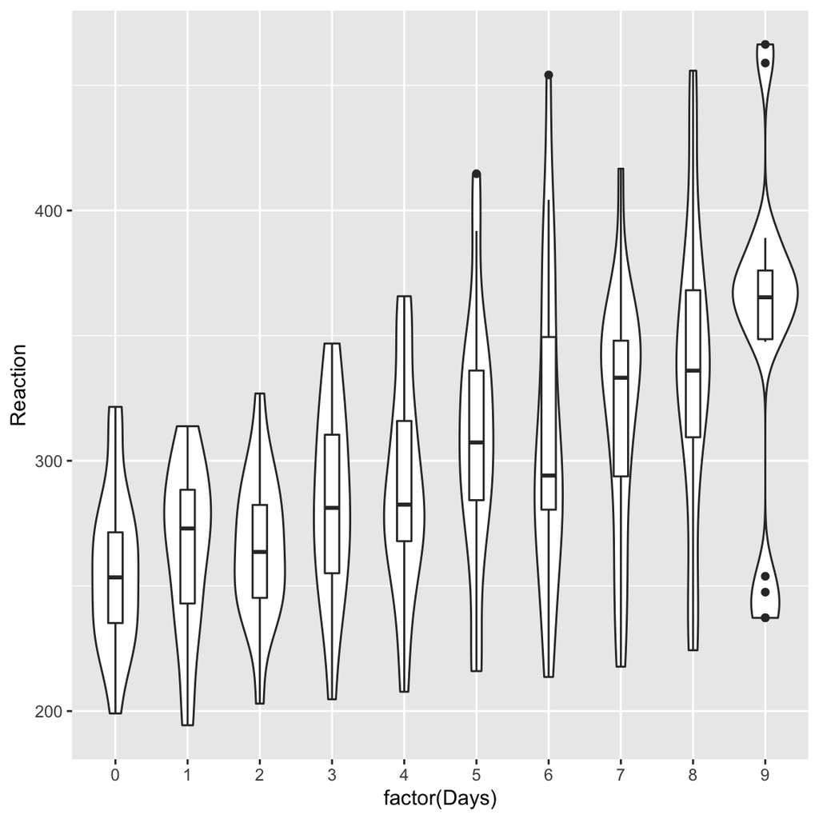

```r
lme4::sleepstudy %>%
  ggplot(aes(factor(Days), Reaction)) +
  geom_violin() +
  geom_boxplot(width=.2)
```

## Labelling axes

`#extension`

- `xlab()` and `ylab()` change x and y axis labels
- [Color labels can also be changed](https://www.datanovia.com/en/blog/ggplot-legend-title-position-and-labels/)
- [Labels in facets are fiddly but also possible](https://www.datanovia.com/en/blog/how-to-change-ggplot-facet-labels/)

# Statistics

Students are taught Bayesian techniques first and supervisors should tend to encourage this too. Start by loading the BayesFactor package:

```r
library(BayesFactor)
```

## Model ‘formula’

Most model functions in R accept a **formula** which describes the outcome and predictor variables (we avoid using dependent and independent variable nomenclature because researchers frequently misuse it when some or all variables are observed rather than manipulated).

Some functions, like t-test, have an alternative method for wide-format data, but this is relatively rare and it is better for students to get used to using model formulae.

A formula always has three parts:

```
y ~ x
```

1. The ‘left hand side’, `y`, which is the outcome
2. The *tilde* symbol, `~`, which means “is predicted by”
3. The ‘right hand side’, `x`, which is the predictor(s)

You can add multiple additive predictors using the `+` symbol:

```
y ~ x1 + x2 ...
```

Or add interactions between variables with the `*`:

```
y ~ x1 * x2 * x3
```

If you write it this way all 2nd and 3rd-level interactions would be included.

Some more complex models require more than one variable on the left hand side, or can combine more than once formula (e.g. for SEM) but we don’t teach these on any of the programmes.

## Compare two groups

### Two independent samples:

#### Bayesian

```r
ttestBF(formula= mpg ~ am, data=mtcars)
```

```
## Bayes factor analysis
## --------------
## [1] Alt., r=0.707 : 86.58973 ±0%
##
## Against denominator:
##   Null, mu1-mu2 = 0
## ---
## Bayes factor type: BFindepSample, JZS
```

#### Frequentist

```r
t.test(mpg ~ am, data=mtcars)
```

```
##
##  Welch Two Sample t-test
##
## data:  mpg by am
## t = -3.7671, df = 18.332, p-value = 0.001374
## alternative hypothesis: true difference in means is not equal to 0
## 95 percent confidence interval:
##  -11.280194  -3.209684
## sample estimates:
## mean in group 0 mean in group 1
##        17.14737        24.39231
```

### Compare two paired samples

`#extension` Note: students aren’t taught paired-samples t-test and are suggested to use a within-Anova with 2 levels of a single factor. This is statistically equivalent and will give you the same answer. See below for how to do it.

If you really want to do a ttest, we need to make an example dataset in the right format first (if you know a built in example in R let me know):

```r
paired.data <- lme4::sleepstudy %>%
  filter(Days==1 | Days==9) %>%
  mutate(Days=paste0('day', Days)) %>%
  pivot_wider(names_from=Days, values_from=Reaction)

paired.data
```

```
## # A tibble: 18 x 3
##    Subject  day1  day9
##    <fct>   <dbl> <dbl>
##  1 308      259.  466.
##  2 309      205.  237.
##  3 310      194.  248.
##  4 330      300.  354.
##  5 331      285   372.
##  6 332      243.  254.
##  7 333      290.  362.
##  8 334      276.  377.
##  9 335      274.  237.
## 10 337      314.  459.
## 11 349      230.  352.
## 12 350      243.  389.
## 13 351      300.  348.
## 14 352      298.  389.
## 15 369      268.  367.
## 16 370      235.  372.
## 17 371      272.  369.
## 18 372      273.  364.
```

#### Bayesian

```r
with(paired.data, ttestBF(day1, day9, paired=TRUE))
```

```
## Bayes factor analysis
## --------------
## [1] Alt., r=0.707 : 3966.803 ±0%
##
## Against denominator:
##   Null, mu = 0
## ---
## Bayes factor type: BFoneSample, JZS
```

#### Frequentist

```r
with(paired.data, t.test(day1, day9, paired=TRUE))
```

```
##
##  Paired t-test
##
## data:  day1 and day9
## t = -6.5205, df = 17, p-value = 5.236e-06
## alternative hypothesis: true difference in means is not equal to 0
## 95 percent confidence interval:
##  -114.29724  -58.41369
## sample estimates:
## mean of the differences
##               -86.35547
```

### More than 2 groups, everything between subjects

Optionally with interactions too:

#### Bayesian

```r
wool.anova <- anovaBF(breaks ~ wool * tension, data=warpbreaks)
wool.anova
```

```
## Bayes factor analysis
## --------------
## [1] wool                          : 0.8184672 ±0.01%
## [2] tension                       : 21.451    ±0.01%
## [3] wool + tension                : 22.64983  ±1.82%
## [4] wool + tension + wool:tension : 69.5641   ±2.15%
##
## Against denominator:
##   Intercept only
## ---
## Bayes factor type: BFlinearModel, JZS
```

- We can read lines 1 and 2 of the output as ‘main effects’.
- Line 3 is the combined effect of wool and tension

Line 4 should not be interpreted on it’s own. Instead, compare it to line 3:

```r
wool.anova[4]/wool.anova[3]
```

```
## Bayes factor analysis
## --------------
## [1] wool + tension + wool:tension : 3.071286 ±2.82%
##
## Against denominator:
##   breaks ~ wool + tension
## ---
## Bayes factor type: BFlinearModel, JZS
```

This is the BF*10* in favour of the interaction.

#### Frequentist

If you don’t have interactions it won’t matter, but if you have interactions you [probably want to report type 3 sums of squares](https://mcfromnz.wordpress.com/2011/03/02/anova-type-iiiiii-ss-explained/).

```r
car::Anova(lm(breaks ~ wool * tension, data=warpbreaks), type=3)
```

```
## Anova Table (Type III tests)
##
## Response: breaks
##               Sum Sq Df  F value    Pr(>F)
## (Intercept)  17866.8  1 149.2757 2.426e-16 ***
## wool          1200.5  1  10.0301 0.0026768 **
## tension       2468.5  2  10.3121 0.0001881 ***
## wool:tension  1002.8  2   4.1891 0.0210442 *
## Residuals     5745.1 48
## ---
## Signif. codes:  0 '***' 0.001 '**' 0.01 '*' 0.05 '.' 0.1 ' ' 1
```

Note, although most people don’t you should probably correct for multiple comparisons after completing 2 way Anova. From Cramer et al, 2016:

> Many psychologists do not realize that exploratory use of the popular multiway analysis of variance harbors a multiple-comparison problem. In the case of two factors, three separate null hypotheses are subject to test (i.e., two main effects and one interaction). Consequently, the probability of at least one Type I error (if all null hypotheses are true) is 14 % rather than 5 %, if the three tests are independent. We explain the multiple-comparison problem and demonstrate that researchers almost never correct for it. To mitigate the problem, we describe four remedies: the omnibus F test, control of the familywise error rate, control of the false discovery rate, and preregistration of the hypotheses.

Cramer, A. O., van Ravenzwaaij, D., Matzke, D., Steingroever, H., Wetzels, R., Grasman, R. P., … & Wagenmakers, E. J. (2016). Hidden multiplicity in exploratory multiway ANOVA: Prevalence and remedies. Psychonomic bulletin & review, 23(2), 640-647.

[Gelman, Hill and Yajima (2012)](http://www.stat.columbia.edu/~gelman/research/published/multiple2f.pdf) explain why this isn’t a problem for the Bayesian approach above.

### Repeated measures/Within subjects Anova

#### Bayesian

The BayesFactor package is fussy about a few things:

- Missing data in the outcome (remove non complete rows with `filter`)
- Non-factor variables (convert numbers or strings to factors or ordered factors first)

```r
sleep <- lme4::sleepstudy %>%
  mutate(Days=ordered(Days))
```

The BF for an effect of `Days` is very large. Also note the ordering of days is being ignored in this model:

```r
anovaBF(Reaction ~ Days + Subject, whichRandom="Subject", data=sleep)
```

```
## Bayes factor analysis
## --------------
## [1] Days + Subject : 5.138088e+17 ±0.39%
##
## Against denominator:
##   Reaction ~ Subject
## ---
## Bayes factor type: BFlinearModel, JZS
```

Adding interactions etc. works as for between-subject models shown above. Make sure you test the interaction properly: you probbaaly want to compare it to the next most complicated model, not the null model .

#### Frequentist

For our stage 4 guide to traditional Anova see: https://www.andywills.info/rminr/more-on-anova.html (this page is quite concise already so not repeated here).

`#extension` We don’t teach this, but this alternative method can be useful for calculating effect size measures:

```r
ez::ezANOVA(sleep, dv = Reaction, wid = Subject, within=Days) %>%
  pander::pander()
```

- **ANOVA**:

  |  | Effect | DFn | DFd | F | p | p<.05 | ges |
  | --- | --- | --- | --- | --- | --- | --- | --- |
  | **2** | Days | 9 | 153 | 18.7 | 8.995e-21 | * | 0.2927 |

- **Mauchly’s Test for Sphericity**:

  |  | Effect | W | p | p<.05 |
  | --- | --- | --- | --- | --- |
  | **2** | Days | 0.000219 | 5.155e-08 | * |

- **Sphericity Corrections**:

  |  | Effect | GGe | p[GG] | p[GG]<.05 | HFe | p[HF] | p[HF]<.05 |
  | --- | --- | --- | --- | --- | --- | --- | --- |
  | **2** | Days | 0.369 | 5.463e-09 | * | 0.4694 | 7.077e-11 | * |

See the `ezANOVA` help file for the horrible details of specifying more complex designs.

## Regression and Ancova

### Ancova: Between subjects factor with continuous covariate

#### Bayesian

This assumes you want to test the effect of a factor (`Species`) conditional on a covariate (`Sepal.Width`):

```r
# calculate a base model with the covariate
h0 <- lmBF(Petal.Length ~ Sepal.Width ,  data=iris)
# an model of interest with the factor added
h1 <- lmBF(Petal.Length ~ Sepal.Width * Species,  data=iris)
```

To get the BF10 for effect of the factor, conditional on the covariate:

```r
h1 / h0
```

```
## Bayes factor analysis
## --------------
## [1] Sepal.Width * Species : 7.87998e+86 ±3.38%
##
## Against denominator:
##   Petal.Length ~ Sepal.Width
## ---
## Bayes factor type: BFlinearModel, JZS
```

#### Frequentist

```r
iris.ancova <- lm(Petal.Length ~ Sepal.Width * Species,  data=iris)
car::Anova(iris.ancova)
```

```
## Anova Table (Type II tests)
##
## Response: Petal.Length
##                     Sum Sq  Df   F value    Pr(>F)
## Sepal.Width           3.89   1   26.1913 9.726e-07 ***
## Species             355.76   2 1198.2894 < 2.2e-16 ***
## Sepal.Width:Species   1.96   2    6.5973  0.001814 **
## Residuals            21.38 144
## ---
## Signif. codes:  0 '***' 0.001 '**' 0.01 '*' 0.05 '.' 0.1 ' ' 1
```

`#extension` If you want to see the covariate slopes and simple-effects (i.e. the dummy coded parameters):

```r
iris.ancova %>%
  broom::tidy() %>%
  pander::pander(caption="Ancova covariate and dummy coded parameters.")
```

Ancova covariate and dummy coded parameters.

| term | estimate | std.error | statistic | p.value |
| --- | --- | --- | --- | --- |
| (Intercept) | 1.183 | 0.5007 | 2.362 | 0.01949 |
| Sepal.Width | 0.08141 | 0.1452 | 0.5607 | 0.5759 |
| Speciesversicolor | 0.752 | 0.6998 | 1.075 | 0.2844 |
| Speciesvirginica | 2.328 | 0.7151 | 3.256 | 0.001411 |
| Sepal.Width:Speciesversicolor | 0.758 | 0.2277 | 3.329 | 0.001108 |
| Sepal.Width:Speciesvirginica | 0.6049 | 0.2241 | 2.699 | 0.007776 |

## Multiple regression

### Multiple predictors and hierarchial steps

#### Bayesian

We need to compare two models to test a single parameter. First run models *with* and then *without* the parameter you’re interested in:

```r
h1 <- lmBF(mpg ~ wt + hp, data=mtcars)
h0 <- lmBF(mpg ~ wt, data=mtcars)
```

Then test if it improves the model (it does here) by dividing their Bayes Factors to get the Bayes Factor for the difference in the models:

```r
h1/h0
```

```
## Bayes factor analysis
## --------------
## [1] wt + hp : 17.27075 ±0.01%
##
## Against denominator:
##   mpg ~ wt
## ---
## Bayes factor type: BFlinearModel, JZS
```

`#extension` This is an easy to test blocks of predictors too — this is hierarchical regression (regression in ‘steps’ if you’re coming from SPSS):

```r
step1 <- lmBF(rating ~ complaints, data=attitude)
step2 <- lmBF(rating ~ complaints + learning + raises + critical, data=attitude)

step2 / step1
```

```
## Bayes factor analysis
## --------------
## [1] complaints + learning + raises + critical : 0.02517264 ±0.01%
##
## Against denominator:
##   rating ~ complaints
## ---
## Bayes factor type: BFlinearModel, JZS
```

This shows evidence against the block of three additional predictors added in step 2.

#### Frequentist

```r
mpg.m <- lm(mpg ~ wt + disp, data=mtcars)
```

Tests of individual parameters:

```r
summary(mpg.m)
```

```
##
## Call:
## lm(formula = mpg ~ wt + disp, data = mtcars)
##
## Residuals:
##     Min      1Q  Median      3Q     Max
## -3.4087 -2.3243 -0.7683  1.7721  6.3484
##
## Coefficients:
##             Estimate Std. Error t value Pr(>|t|)
## (Intercept) 34.96055    2.16454  16.151 4.91e-16 ***
## wt          -3.35082    1.16413  -2.878  0.00743 **
## disp        -0.01773    0.00919  -1.929  0.06362 .
## ---
## Signif. codes:  0 '***' 0.001 '**' 0.01 '*' 0.05 '.' 0.1 ' ' 1
##
## Residual standard error: 2.917 on 29 degrees of freedom
## Multiple R-squared:  0.7809, Adjusted R-squared:  0.7658
## F-statistic: 51.69 on 2 and 29 DF,  p-value: 2.744e-10
```

Or get test results as a dataframe:

```r
# the `statistic` column is the t statstic here
broom::tidy(mpg.m)
```

```
## # A tibble: 3 x 5
##   term        estimate std.error statistic  p.value
##   <chr>          <dbl>     <dbl>     <dbl>    <dbl>
## 1 (Intercept)  35.0      2.16        16.2  4.91e-16
## 2 wt           -3.35     1.16        -2.88 7.43e- 3
## 3 disp         -0.0177   0.00919     -1.93 6.36e- 2
```

`#extension` Testing steps:

```r
step1 <- lm(rating ~ complaints, data=attitude)
step2 <- lm(rating ~ complaints + learning + raises + critical, data=attitude)

anova(step2, step1)
```

```
## Analysis of Variance Table
##
## Model 1: rating ~ complaints + learning + raises + critical
## Model 2: rating ~ complaints
##   Res.Df    RSS Df Sum of Sq      F Pr(>F)
## 1     25 1253.2
## 2     28 1369.4 -3   -116.16 0.7724 0.5204
```

### Interactions in regression

#### Bayesian

```r
# note + vs * in formula
h1 <- lmBF(mpg ~ wt * hp, data=mtcars)
h0 <- lmBF(mpg ~ wt + hp, data=mtcars)

h1/h0
```

```
## Bayes factor analysis
## --------------
## [1] wt * hp : 30.43604 ±0%
##
## Against denominator:
##   mpg ~ wt + hp
## ---
## Bayes factor type: BFlinearModel, JZS
```

#### Frequentist

```r
# note + vs * in formula
h1 <- lm(mpg ~ wt * hp, data=mtcars)
h0 <- lm(mpg ~ wt + hp, data=mtcars)

anova(h1, h0)
```

```
## Analysis of Variance Table
##
## Model 1: mpg ~ wt * hp
## Model 2: mpg ~ wt + hp
##   Res.Df    RSS Df Sum of Sq      F    Pr(>F)
## 1     28 129.76
## 2     29 195.05 -1   -65.286 14.088 0.0008108 ***
## ---
## Signif. codes:  0 '***' 0.001 '**' 0.01 '*' 0.05 '.' 0.1 ' ' 1
```

Or just:

```r
anova(h1)
```

```
## Analysis of Variance Table
##
## Response: mpg
##           Df Sum Sq Mean Sq F value    Pr(>F)
## wt         1 847.73  847.73 182.923 8.428e-14 ***
## hp         1  83.27   83.27  17.969 0.0002207 ***
## wt:hp      1  65.29   65.29  14.088 0.0008108 ***
## Residuals 28 129.76    4.63
## ---
## Signif. codes:  0 '***' 0.001 '**' 0.01 '*' 0.05 '.' 0.1 ' ' 1
```

### Quadratic/polynomial terms in regression

`#extension` This looks a bit non-linear so we might want to test polynomial effects:

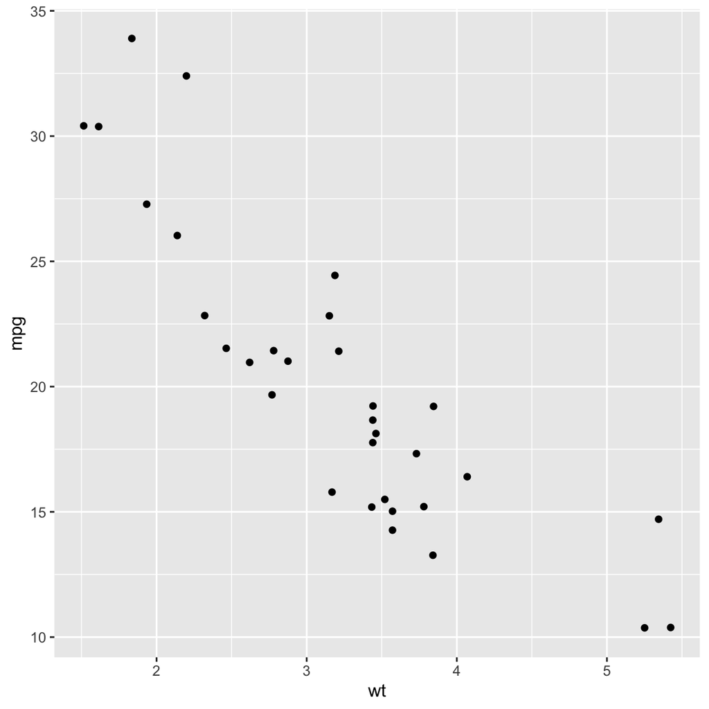

```r
mtcars %>%
  ggplot(aes(wt, mpg)) +
  geom_jitter()
```

#### Bayesian

```r
# it's annoying but we have to add the column to the df first
# because lmBF won't allow arithmetic inside it's formula

mtcars.poly <- mtcars %>%
  mutate(wt_2 = poly(wt,2))

h1 <- lmBF(mpg ~ wt + wt_2, data=mtcars.poly)
h0 <- lmBF(mpg ~ wt, data=mtcars.poly)

h1/h0
```

```
## Bayes factor analysis
## --------------
## [1] wt + wt_2 : 9.502005 ±0.01%
##
## Against denominator:
##   mpg ~ wt
## ---
## Bayes factor type: BFlinearModel, JZS
```

#### Frequentist

```r
h1 <- lm(mpg ~ poly(wt, 2), data=mtcars)
summary(h1) # look at the p value for the second poly term
```

```
##
## Call:
## lm(formula = mpg ~ poly(wt, 2), data = mtcars)
##
## Residuals:
##    Min     1Q Median     3Q    Max
## -3.483 -1.998 -0.773  1.462  6.238
##
## Coefficients:
##              Estimate Std. Error t value Pr(>|t|)
## (Intercept)   20.0906     0.4686  42.877  < 2e-16 ***
## poly(wt, 2)1 -29.1157     2.6506 -10.985 7.52e-12 ***
## poly(wt, 2)2   8.6358     2.6506   3.258  0.00286 **
## ---
## Signif. codes:  0 '***' 0.001 '**' 0.01 '*' 0.05 '.' 0.1 ' ' 1
##
## Residual standard error: 2.651 on 29 degrees of freedom
## Multiple R-squared:  0.8191, Adjusted R-squared:  0.8066
## F-statistic: 65.64 on 2 and 29 DF,  p-value: 1.715e-11
```

## Model statistics

Extract R<sup>2</sup> and other statistics from any linear model:

```r
iris.ancova %>%
  broom::glance() %>%
  pivot_longer(everything())
```

```
## # A tibble: 11 x 2
##    name              value
##    <chr>             <dbl>
##  1 r.squared      9.54e- 1
##  2 adj.r.squared  9.52e- 1
##  3 sigma          3.85e- 1
##  4 statistic      5.97e+ 2
##  5 p.value        2.44e-94
##  6 df             6.00e+ 0
##  7 logLik        -6.67e+ 1
##  8 AIC            1.47e+ 2
##  9 BIC            1.69e+ 2
## 10 deviance       2.14e+ 1
## 11 df.residual    1.44e+ 2
```

## Plotting model results

#### Bayesian

`#extension` You can plot the posterior density of model parameters. It can help to standardise first:

```r
# standardise first
mtcars.z <- scale(mtcars) %>% as_tibble()
h1.z <- lmBF(mpg ~ wt + hp, data=mtcars.z)
```

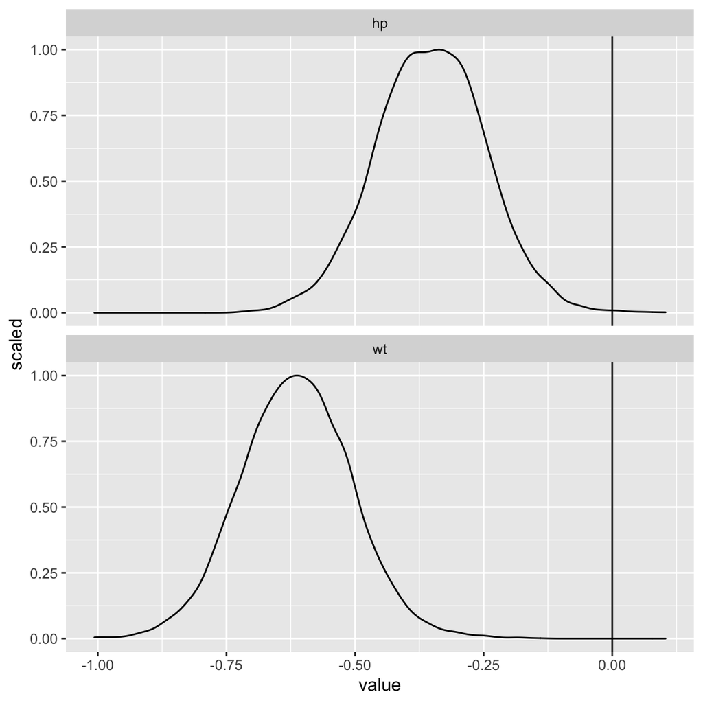

```r
chains = posterior(h1.z, iterations = 5000, progress = FALSE) %>% as_tibble()

chains %>%
  pivot_longer(c(wt, hp)) %>%
  ggplot(aes(value)) +
  geom_density(aes(y=..scaled..)) +
  facet_wrap(~name, ncol=1) +
  geom_vline(xintercept = 0)
```

Or plot intervals:

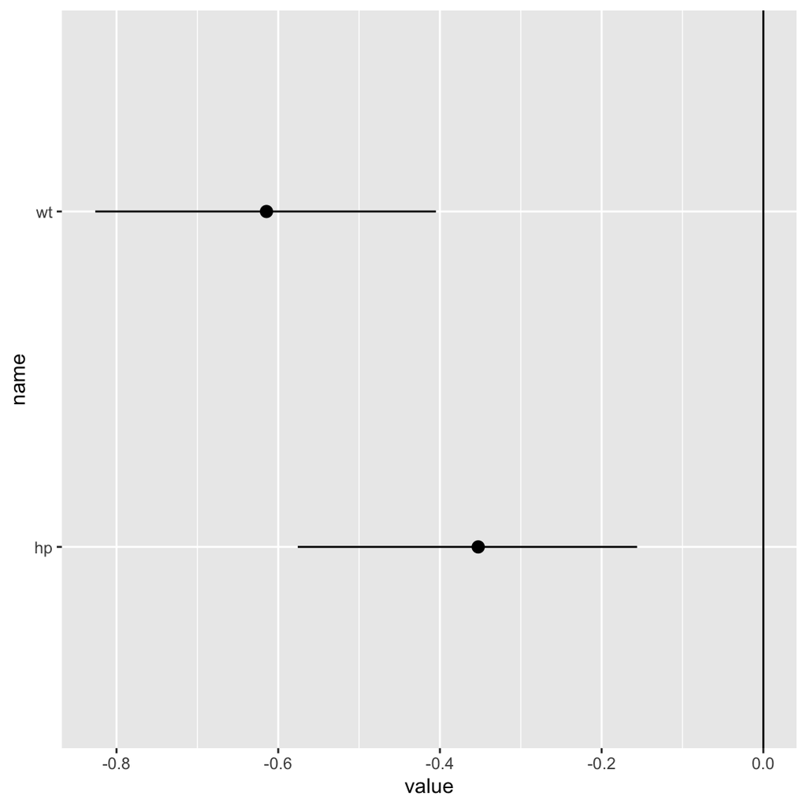

```r
chains %>%
  pivot_longer(c(wt, hp)) %>%
  ggplot(aes(name, value)) +
  # 95th highest density posterior interval, see Krushke book but
  # where these don't cross zero the parameter is 'significant'
  stat_summary(fun.data=tidybayes::mean_hdci) +
  coord_flip() +
  geom_hline(yintercept = 0)
```

#### Frequentist

# Other data handling tasks

## Recoding categorical data

Taught in stage 2 here: https://benwhalley.github.io/rmip/data.html

## Converting continuous and categorical data

### Chopping up a continuous variable into segments (e.g. for ages)

`#extension`

```r
mtcars %>%
  select(wt) %>%
  mutate(wt_categ = cut(wt, 5)) %>%
  sample_n(10)
```

```
##       wt    wt_categ
## 1  3.570 (3.08,3.86]
## 2  3.440 (3.08,3.86]
## 3  2.140  (1.51,2.3]
## 4  1.935  (1.51,2.3]
## 5  2.320  (2.3,3.08]
## 6  3.780 (3.08,3.86]
## 7  2.770  (2.3,3.08]
## 8  3.170 (3.08,3.86]
## 9  2.780  (2.3,3.08]
## 10 2.620  (2.3,3.08]
```

Or with pre-set breaks:

```r
mtcars %>%
  select(wt) %>%
  mutate(wt_categ = cut(wt, breaks = c(-1,1,3,5,Inf))) %>%
  sample_n(10)
```

```
##       wt wt_categ
## 1  3.440    (3,5]
## 2  3.570    (3,5]
## 3  2.875    (1,3]
## 4  3.435    (3,5]
## 5  2.770    (1,3]
## 6  2.620    (1,3]
## 7  2.140    (1,3]
## 8  3.780    (3,5]
## 9  3.520    (3,5]
## 10 2.320    (1,3]
```